# Analysis of Aversive Learning on Orientation Discrimination

Author

Marco Roccato

## 1 Setup and Environment

We first load all the R packages needed for our analysis.

```r
# We load all R packages needed for our analysis.
if (!require("pacman")) install.packages("pacman")
pacman::p_load(
  tidyverse,      # For data manipulation (dplyr, ggplot2)
  here,           # For creating reproducible file paths
  rstatix,        # For easy statistical analysis
  emmeans,        # For post-hoc tests
  performance,    # For outlier detection
  patchwork,      # For combining plots
  kableExtra,     # For beautiful tables
  broom,          # For tidying model output
  BayesFactor     # For Bayesian analysis
)

# We also set a seed for reproducibility.
set.seed(42)
```

## 2 Data Preparation Summary

The analysis pipeline involved several key data preparation steps:

- **Loading & Merging:** 56 individual participant files were loaded and combined.
- **Screening:** All 56 participants passed the memory screening test.
- **Transformation:** Data was converted to a long format, and key factors (`Group`, `CS`) were created.
- **DV Calculation:** The primary dependent variable, `percent_change`, was calculated.
- **Outlier Identification:** A second, ‘cleaned’ dataset was created by removing 10 subjects with extreme scores.

## 3 Participant Balance Check (Full Dataset)

We first confirm that participants in the full dataset (N=56) are reasonably balanced across the experimental conditions.

Participant Counts per Condition (Full Dataset)

| which_group | HORIZONTAL | VERTICAL |
| --- | --- | --- |
| Control | 17 | 13 |
| Aversive | 14 | 12 |

## 4 Pre-Analysis: Baseline Equivalence

We test if the HOR and VER groups had different thresholds at baseline. A non-significant result (p > .05) confirms the groups were equivalent.

Welch Two Sample t-test on Baseline Thresholds

| t | df | p | CI Low | CI High |
| --- | --- | --- | --- | --- |
| -0.968 | 109.373 | 0.335 | -0.427 | 0.147 |

## 5 Pre-Analysis: Normality & Outlier Rationale

The Shapiro-Wilk test checks if the data is normally distributed. A p-value < .05 indicates a significant violation of this assumption.

Shapiro-Wilk Normality Tests (Full Dataset)

| which_group | CS | variable | statistic | p |
| --- | --- | --- | --- | --- |
| Control | CS- | percent_change | 0.685 | 0 |
| Control | CS+ | percent_change | 0.559 | 0 |
| Aversive | CS- | percent_change | 0.591 | 0 |
| Aversive | CS+ | percent_change | 0.700 | 0 |

Since the data severely violated the normality assumption, we performed a robust outlier removal procedure. Outliers were defined as any data point falling outside 1.5 times the Interquartile Range (IQR) from the 25th (Q1) or 75th (Q3) percentile. This identified 10 subjects who were removed for the cleaned analysis.

## 6 Main Analysis (Full Dataset)

We perform a 2x2 mixed-effects ANOVA on the full dataset (N=56). This initial analysis is sensitive to outliers and normality violations.

ANOVA Results (Full Dataset, N=56)

| Effect | DFn | DFd | F | p | p<.05 | ges |
| --- | --- | --- | --- | --- | --- | --- |
| which_group | 1 | 54 | 0.788 | 0.379 |  | 0.007 |
| CS | 1 | 54 | 3.138 | 0.082 |  | 0.029 |
| which_group:CS | 1 | 54 | 0.155 | 0.696 |  | 0.001 |

## 7 Visualization: Full vs. Cleaned

A side-by-side comparison of the data distributions before and after outlier removal.

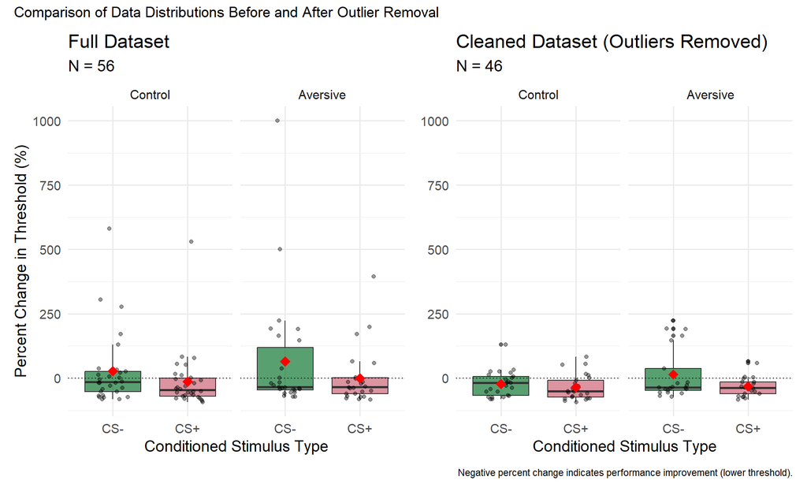

## 8 Participant Balance Check (Cleaned)

We confirm that the groups remain balanced after outlier removal (N=46).

Participant Counts per Condition (Cleaned Dataset)

| which_group | HORIZONTAL | VERTICAL |
| --- | --- | --- |
| Control | 15 | 10 |
| Aversive | 11 | 10 |

## 9 Main Analysis (Cleaned Dataset)

We re-run the ANOVA on the cleaned dataset (N=46) after removing outliers. This provides a more robust test of our hypotheses.

ANOVA Results (Cleaned Dataset, N=46)

Effect

DFn

DFd

F

p

p<.05

ges

which_group

1

44

2.026

0.162

0.025

CS

1

44

5.924

0.019

0.055

which_group:CS

1

44

1.757

0.192

0.017

## 10 Follow-up: Simple Effects Analysis

To check if the CS effect was significant within each group individually, we test the simple effects.

Simple Effects of CS within each Group

| which_group | term | contrast | null.value | estimate | std.error | df | statistic | p.value |
| --- | --- | --- | --- | --- | --- | --- | --- | --- |
| Control | CS | (CS-) - (CS+) | 0 | 13.605 | 16.587 | 44 | 0.82 | 0.417 |
| Aversive | CS | (CS-) - (CS+) | 0 | 46.148 | 18.098 | 44 | 2.55 | 0.014 |

The effect of CS is significant within the Aversive group (`p = .014`) but not the Control group (`p = .417`). However, because the overall interaction from the main ANOVA was not significant, we must interpret this with caution. The most robust conclusion remains the main effect of CS across both groups.

## 11 Bayesian Analysis

To complement the frequentist ANOVA, we quantify the evidence for our effects using Bayes Factors (BF10).

- BF10 > 3: Substantial evidence for the effect.
- BF10 < 1/3: Substantial evidence *for the absence* of an effect.

Bayes Factor Analysis of Effects (Cleaned Data)

| Effect | BF10 |
| --- | --- |
| Group | 0.561 |
| CS | 2.930 |
| Group x CS Interaction | 0.599 |

## 12 Visualization: Cleaned Data

This plot focuses only on the cleaned dataset (N=46), allowing the y-axis to zoom in on the significant effect.

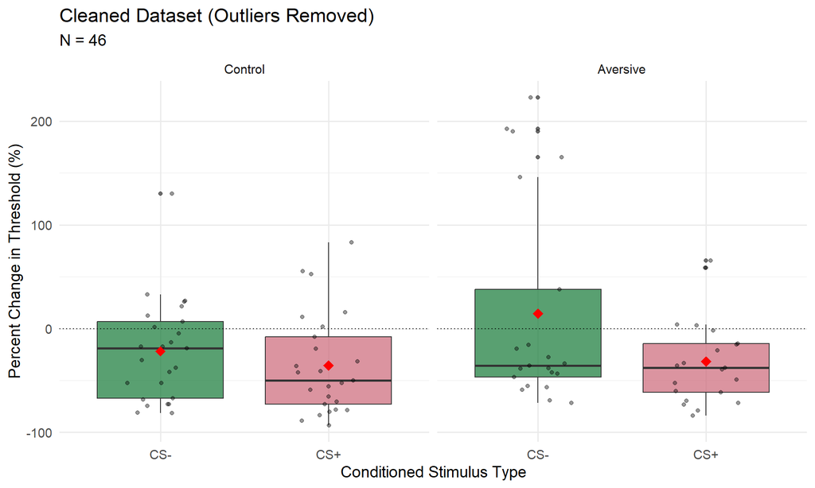

## 15 Alternative Analysis

As an alternative approach to outlier removal, more adherent to the participant exclusion criteria described in Shalev et al. (2018), we can analyze image recall relatively to the images seen during the conditioning phase. Using Signal Detection Theory, allows us to calculate d-prime (d’), a measure of sensitivity that informs on the participant’s ability to discriminate old from new images.

This chunk reloads the raw trial data, focusing on the columns needed for the memory task. It then calculates Hits, Misses, False Alarms, and Correct Rejections for each participant to compute their d’ score usingg the `psycho` package. The final table displays results for all participants with valid memory task data, using scrambled pseudonyms for the IDs.

Memory Sensitivity (d’) and Accuracy per Participant

| # | Pseudonym | Accuracy | d’ | Hits | Misses | False Alarms | Correct Rej. |
| --- | --- | --- | --- | --- | --- | --- | --- |
| 1 | 300AB | 0.90 | 2.194 | 9 | 1 | 1 | 9 |
| 2 | B637A | 0.70 | 0.985 | 8 | 2 | 4 | 6 |
| 3 | D32A0 | 0.85 | 1.849 | 9 | 1 | 2 | 8 |
| 4 | 22A5G | 1.00 | 3.381 | 10 | 0 | 0 | 10 |
| 5 | N313A | 1.00 | 3.381 | 10 | 0 | 0 | 10 |
| 6 | B7B13 | 0.95 | 2.795 | 9 | 1 | 0 | 10 |
| 7 | 4BF38 | 0.75 | 1.223 | 8 | 2 | 3 | 7 |
| 8 | 44CD7 | 0.90 | 2.463 | 8 | 2 | 0 | 10 |
| 9 | 5C26O | 0.95 | 2.795 | 9 | 1 | 0 | 10 |
| 10 | D7B74 | 0.80 | 1.583 | 9 | 1 | 3 | 7 |
| 11 | 3D49C | 0.75 | 1.223 | 7 | 3 | 2 | 8 |
| 12 | 4C32E | 1.00 | 3.381 | 10 | 0 | 0 | 10 |
| 13 | 94E8L | 0.95 | 2.795 | 10 | 0 | 1 | 9 |
| 14 | E5M66 | 0.80 | 1.496 | 8 | 2 | 2 | 8 |
| 15 | 3P56E | 0.60 | 0.460 | 6 | 4 | 4 | 6 |
| 16 | 7F0C7 | 0.95 | 2.795 | 9 | 1 | 0 | 10 |
| 17 | F5G19 | 0.90 | 2.463 | 8 | 2 | 0 | 10 |
| 18 | 297FM | 0.90 | 2.463 | 8 | 2 | 0 | 10 |
| 19 | FT381 | 0.75 | 1.351 | 9 | 1 | 4 | 6 |
| 20 | 2FT17 | 0.90 | 2.463 | 8 | 2 | 0 | 10 |
| 21 | G28C7 | 0.90 | 2.463 | 10 | 0 | 2 | 8 |
| 22 | GC654 | 0.95 | 2.795 | 10 | 0 | 1 | 9 |
| 23 | 9GP49 | 0.95 | 2.795 | 10 | 0 | 1 | 9 |
| 24 | 6G4S0 | 0.75 | 1.351 | 6 | 4 | 1 | 9 |
| 25 | 41C9J | 0.95 | 2.795 | 10 | 0 | 1 | 9 |
| 26 | K224K | 0.95 | 2.795 | 9 | 1 | 0 | 10 |
| 27 | 2B8L4 | 1.00 | 3.381 | 10 | 0 | 0 | 10 |
| 28 | 74BL7 | 0.90 | 2.194 | 9 | 1 | 1 | 9 |
| 29 | 68L5L | 1.00 | 3.381 | 10 | 0 | 0 | 10 |
| 30 | 73M1L | 0.80 | 1.496 | 8 | 2 | 2 | 8 |
| 31 | L81R3 | 0.95 | 2.795 | 9 | 1 | 0 | 10 |
| 32 | 94S4L | 1.00 | 3.381 | 10 | 0 | 0 | 10 |
| 33 | 8MA32 | 0.85 | 2.209 | 7 | 3 | 0 | 10 |
| 34 | MD537 | 0.75 | 1.223 | 8 | 2 | 3 | 7 |
| 35 | 3G1M3 | 0.90 | 2.463 | 8 | 2 | 0 | 10 |
| 36 | 5G51M | 0.60 | 0.476 | 5 | 5 | 3 | 7 |
| 37 | M910M | 0.75 | 1.351 | 6 | 4 | 1 | 9 |
| 38 | 70MM5 | 0.80 | 1.583 | 7 | 3 | 1 | 9 |
| 39 | 4P3M1 | 0.90 | 2.463 | 8 | 2 | 0 | 10 |
| 40 | 0M5T1 | 0.65 | 0.912 | 4 | 6 | 1 | 9 |
| 41 | M8Z09 | 0.95 | 2.795 | 9 | 1 | 0 | 10 |
| 42 | 72CN1 | 0.80 | 1.583 | 9 | 1 | 3 | 7 |
| 43 | 08PN4 | 0.80 | 1.583 | 7 | 3 | 1 | 9 |
| 44 | 91MP7 | 0.85 | 1.849 | 8 | 2 | 1 | 9 |
| 45 | R47C9 | 0.80 | 1.583 | 7 | 3 | 1 | 9 |
| 46 | 3C66R | 0.90 | 2.463 | 10 | 0 | 2 | 8 |
| 47 | R99F6 | 0.85 | 1.849 | 9 | 1 | 2 | 8 |
| 48 | R17G7 | 0.95 | 2.795 | 10 | 0 | 1 | 9 |
| 49 | 21R6R | 0.85 | 2.209 | 10 | 0 | 3 | 7 |
| 50 | S8B53 | 0.90 | 2.194 | 9 | 1 | 1 | 9 |
| 51 | 3DS16 | 0.75 | 1.351 | 6 | 4 | 1 | 9 |
| 52 | S409S | 0.80 | 1.990 | 6 | 4 | 0 | 10 |
| 53 | T2C65 | 0.95 | 2.795 | 9 | 1 | 0 | 10 |
| 54 | T314M | 0.80 | 1.496 | 8 | 2 | 2 | 8 |
| 55 | U96U2 | 0.90 | 2.463 | 10 | 0 | 2 | 8 |
| 56 | 15V8E | 0.70 | 0.985 | 8 | 2 | 4 | 6 |

### 15.1 Participant Count After Memory Test

After calculating memory sensitivity, we exclude participants who were not performing the memory task adequately, operationally defined as having a d’ score below 1.0. This criterion is more stringent than the 55% success cutoff used by SHalev et al. (2018). This ensures that the main analysis is conducted only on subjects who successfully engaged with the conditioning paradigm.

The following code block filters the dataset based on this d’ criterion and provides a final count of the participants retained for analysis in each experimental group.

Final Count of Participants (d’ >= 1) by Group and Conditioned Stimulus

| which_group | conditioned | Retained Participant Count |
| --- | --- | --- |
| Control | HORIZONTAL | 15 |
| Control | VERTICAL | 13 |
| Aversive | HORIZONTAL | 12 |
| Aversive | VERTICAL | 11 |

Unified Validation Screening and Final Participant Count In this revised analysis, we apply a consistent set of screening criteria to all participants. Participants are retained for the final analysis only if they meet both of the following criteria:

Memory Performance: d’ score >= 1.

Emotional Rating Validation: A rating difference of at least 1.5 points between the aversive and neutral image categories, and an average rating for aversive images greater than 4.

This unified process is applied to both the Control and Aversive groups to create the final dataset.

### 15.2 Validation Test Results for All Memory-Retained Participants

Participants who fail the validation criteria are flagged in red.

| Subject ID | Group | Aversive Rating | Neutral Rating | Difference | Meets Criteria |
| --- | --- | --- | --- | --- | --- |
| AB300 | Aversive | 7.13 | 2.10 | 5.03 | TRUE |
| AD230 | Aversive | 7.27 | 3.00 | 4.27 | TRUE |
| AG522 | Aversive | 6.50 | 2.80 | 3.70 | TRUE |
| AN331 | Control | 7.40 | 2.60 | 4.80 | TRUE |
| BB173 | Aversive | 7.27 | 2.50 | 4.77 | TRUE |
| BF483 | Aversive | 6.77 | 2.50 | 4.27 | TRUE |
| CD447 | Aversive | 6.60 | 3.00 | 3.60 | TRUE |
| CO256 | Aversive | 5.13 | 2.10 | 3.03 | TRUE |
| DB477 | Aversive | 3.60 | 2.30 | 1.30 | FALSE |
| DC394 | Control | 6.80 | 4.17 | 2.63 | TRUE |
| EC432 | Aversive | 5.80 | 2.50 | 3.30 | TRUE |
| EL894 | Control | 7.70 | 4.50 | 3.20 | TRUE |
| EM665 | Aversive | 4.63 | 2.40 | 2.23 | TRUE |
| FC770 | Control | 6.50 | 2.00 | 4.50 | TRUE |
| FG591 | Control | 7.20 | 3.83 | 3.37 | TRUE |
| FM927 | Control | 7.30 | 4.50 | 2.80 | TRUE |
| FT138 | Aversive | 3.63 | 2.00 | 1.63 | FALSE |
| FT271 | Control | 6.20 | 3.00 | 3.20 | TRUE |
| GC278 | Aversive | 7.07 | 2.90 | 4.17 | TRUE |
| GC456 | Control | 6.70 | 2.80 | 3.90 | TRUE |
| GP499 | Control | 6.30 | 3.97 | 2.33 | TRUE |
| GS406 | Control | 7.50 | 2.73 | 4.77 | TRUE |
| JC419 | Control | 6.60 | 4.27 | 2.33 | TRUE |
| KK242 | Control | 6.60 | 4.73 | 1.87 | TRUE |
| LB428 | Control | 7.50 | 2.50 | 5.00 | TRUE |
| LB477 | Aversive | 7.03 | 2.90 | 4.13 | TRUE |
| LL568 | Control | 7.50 | 3.10 | 4.40 | TRUE |
| LM317 | Aversive | 5.13 | 4.70 | 0.43 | FALSE |
| LR813 | Control | 3.70 | 2.87 | 0.83 | FALSE |
| LS449 | Control | 5.80 | 3.37 | 2.43 | TRUE |
| MA382 | Control | 6.80 | 2.60 | 4.20 | TRUE |
| MD735 | Aversive | 6.27 | 2.20 | 4.07 | TRUE |
| MG133 | Aversive | 6.50 | 2.10 | 4.40 | TRUE |
| MM109 | Control | 7.40 | 3.00 | 4.40 | TRUE |
| MM507 | Control | 6.60 | 4.43 | 2.17 | TRUE |
| MP431 | Control | 2.80 | 2.10 | 0.70 | FALSE |
| MZ908 | Control | 5.90 | 3.20 | 2.70 | TRUE |
| NC127 | Aversive | 6.77 | 3.40 | 3.37 | TRUE |
| NP840 | Control | 7.80 | 2.23 | 5.57 | TRUE |
| PM791 | Aversive | 4.67 | 2.00 | 2.67 | TRUE |
| RC479 | Aversive | 6.70 | 3.20 | 3.50 | TRUE |
| RC663 | Aversive | 6.83 | 2.50 | 4.33 | TRUE |
| RF699 | Aversive | 3.33 | 2.80 | 0.53 | FALSE |
| RG771 | Control | 6.40 | 4.50 | 1.90 | TRUE |
| RR261 | Aversive | 6.77 | 2.10 | 4.67 | TRUE |
| SB385 | Control | 7.30 | 2.87 | 4.43 | TRUE |
| SD316 | Control | 6.80 | 2.47 | 4.33 | TRUE |
| SS940 | Control | 5.90 | 2.80 | 3.10 | TRUE |
| TC526 | Control | 5.80 | 2.47 | 3.33 | TRUE |
| TM431 | Control | 5.80 | 4.13 | 1.67 | TRUE |
| UU926 | Aversive | 5.37 | 2.60 | 2.77 | TRUE |

### Final Participant Count After All Screening

Final Participant Count After Unified Memory and Validation Screening

| which_group | conditioned | Final Retained Count |
| --- | --- | --- |
| Control | HORIZONTAL | 13 |
| Control | VERTICAL | 13 |
| Aversive | HORIZONTAL | 9 |
| Aversive | VERTICAL | 10 |

This table provides the final participant count after applying the stricter, unified screening criteria to both experimental groups. This is the final N that will be used for subsequent analyses.

### 15.3 Baseline Equivalence Check (Final Screened Dataset)

Before running the main analysis on the final, doubly-screened dataset, we must confirm that the groups and conditions were equivalent at the baseline measurement. We will perform two Welch Two Sample t-tests on the baseline thresholds of the retained participants to check for any pre-existing differences.

Group Equivalence: Test for differences between the Aversive and Control groups.

Orientation Equivalence: Test for differences between the HORIZONTAL and VERTICAL conditioned stimuli.

A non-significant result (p > .05) in both tests will confirm that any effects observed in the main analysis are not due to pre-existing differences.

t-test on Baseline Thresholds by Group (Final Dataset)

| t | df | p | CI Low | CI High |
| --- | --- | --- | --- | --- |
| 2.277 | 87.558 | 0.025 | 0.042 | 0.626 |

t-test on Baseline Thresholds by Orientation (Final Dataset)

| t | df | p | CI Low | CI High |
| --- | --- | --- | --- | --- |
| -0.792 | 87.97 | 0.43 | -0.428 | 0.184 |

### 15.4 Plot percent change after memory test and validation test

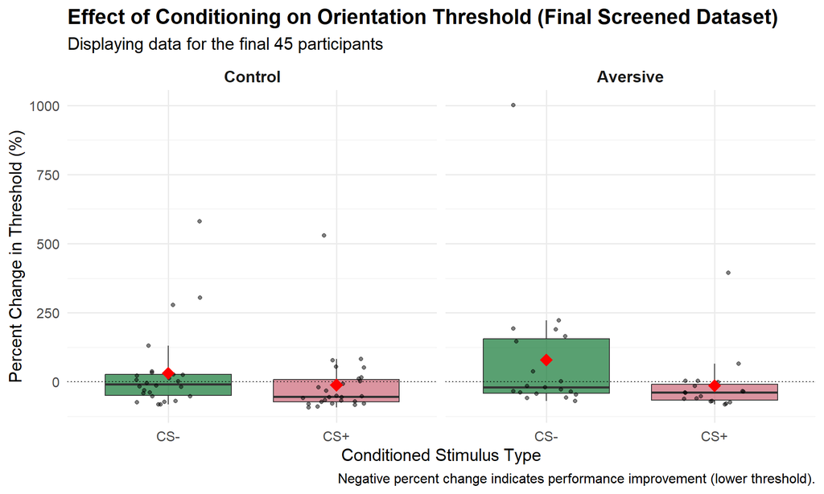

### 15.5 Robust Outlier Removal Using Median Absolute Deviation (MAD)

Given the presence of extreme outliers in the final dataset, we will apply a robust outlier removal procedure before visualization and final analysis. The Median Absolute Deviation (MAD) method is used because it is not sensitive to the very outliers we are trying to detect.

An observation is flagged as an outlier if it falls outside the median by more than 3.5 times the MAD. To maintain a balanced design for paired analysis, if any single data point from a participant is identified as an outlier, all data from that participant will be removed.

### 15.6 Note: 9 participant(s) were identified and removed due to having extreme outliers.

### 15.7 Final Participant Count by Group and Condition

Participant Count in Each Condition After All Exclusions

| which_group | CS | n |
| --- | --- | --- |
| Control | CS- | 22 |
| Control | CS+ | 22 |
| Aversive | CS- | 14 |
| Aversive | CS+ | 14 |

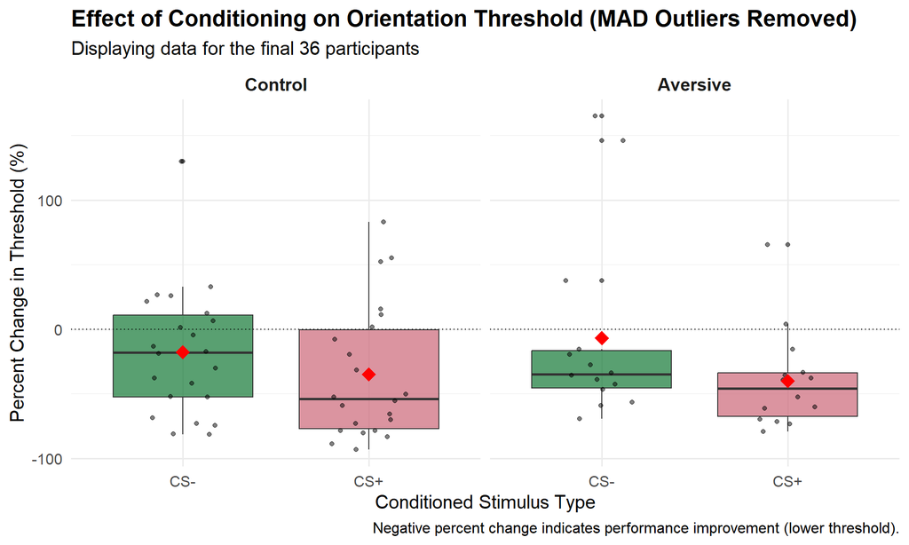

### 15.8 Final ANCOVA on Robustly Cleaned Data

On the final, robustly cleaned dataset with outliers removed (mad_cleaned_df), we can proceed with ANCOVA.

Mixed ANCOVA Results (MAD Outliers Removed)

|  | Sum Sq | Mean Sq | NumDF | DenDF | F value | Pr(>F) |
| --- | --- | --- | --- | --- | --- | --- |
| Baseline | 1.014 | 1.014 | 1 | 67 | 9.288 | 0.003 |
| which_group | 0.134 | 0.134 | 1 | 67 | 1.228 | 0.272 |
| CS | 0.150 | 0.150 | 1 | 67 | 1.370 | 0.246 |
| which_group:CS | 0.008 | 0.008 | 1 | 67 | 0.074 | 0.787 |

### 15.9 Follow-up: Paired t-tests on Percent Change

Although the main ANCOVA did not reveal a significant interaction, we can perform paired t-tests within each group to directly compare the percent change for the CS+ and CS- conditions. This addresses the specific hypothesis of whether a conditioning effect (as measured by relative change from baseline) occurred within either the Control or Aversive group individually.

These results should be interpreted with caution, as the overall ANCOVA did not support a differential effect between the groups.

### 15.10 Paired t-test on Percent Change for: Control Group

Paired t-test on Percent Change (CS+ vs. CS-) for the Control Group

| statistic | p.value | parameter | conf.low | conf.high |
| --- | --- | --- | --- | --- |
| 0.987 | 0.335 | 21 | -19.032 | 53.397 |

### Paired t-test on Percent Change for: Aversive Group

Paired t-test on Percent Change (CS+ vs. CS-) for the Aversive Group

| statistic | p.value | parameter | conf.low | conf.high |
| --- | --- | --- | --- | --- |
| 2.124 | 0.053 | 13 | -0.564 | 66.785 |

Alternative Analysis: ANOVA on Percent Change As an alternative to the ANCOVA, we can perform a mixed-design ANOVA directly on the percent_change variable. This approach tests whether the relative change in threshold from baseline differs between our experimental conditions.

Before running the ANOVA, we its assumptions on the final, robustly cleaned dataset (mad_cleaned_df). We will check for:

Normality: The Shapiro-Wilk test will be used to check if the percent_change data within each of the four experimental cells is normally distributed.

Homogeneity of Variances: Levene’s test will be used to ensure that the variance of percent_change is equal across the Control and Aversive groups.

### 15.11 Assumption Check 1: Normality (Shapiro-Wilk Test)

Shapiro-Wilk Normality Tests on Final Dataset

| which_group | CS | variable | statistic | p |
| --- | --- | --- | --- | --- |
| Control | CS- | percent_change | 0.913 | 0.054 |
| Control | CS+ | percent_change | 0.886 | 0.016 |
| Aversive | CS- | percent_change | 0.713 | 0.001 |
| Aversive | CS+ | percent_change | 0.839 | 0.016 |

### Assumption Check 2: Homogeneity of Variances (Levene’s Test)

Levene’s Test for Homogeneity of Variances

| df1 | df2 | statistic | p |
| --- | --- | --- | --- |
| 1 | 70 | 0.452 | 0.504 |

### Mixed ANOVA on Percent Change

Mixed ANOVA Results on Percent Change (Final Dataset)

| Effect | DFn | DFd | F | p | p<.05 | ges |
| --- | --- | --- | --- | --- | --- | --- |
| which_group | 1 | 34 | 0.046 | 0.831 |  | 0.001 |
| CS | 1 | 34 | 3.992 | 0.054 |  | 0.052 |
| which_group:CS | 1 | 34 | 0.400 | 0.531 |  | 0.005 |

Non-Parametric Mixed ANOVA (Aligned Rank Transform) Given that the assumption of normality was violated in several of the experimental cells, we will use a non-parametric equivalent of a mixed ANOVA. The Aligned Rank Transform (ART) ANOVA is a robust procedure that allows for testing main effects and interactions in a factorial design without assuming normality of the data.

Non-Parametric Mixed ANOVA Results on Percent Change

|  | Term | F | Df | Df.res | Pr(>F) |
| --- | --- | --- | --- | --- | --- |
| which_group | which_group | 0.019 | 1 | 34 | 0.892 |
| CS | CS | 3.170 | 1 | 34 | 0.084 |
| which_group:CS | which_group:CS | 0.018 | 1 | 34 | 0.894 |

Initial Dataset: The analysis started with 56 participants.

After memory test, validation test, and MAD outlier rejection, only 36 participants (22 Control, 14 Aversive conditioning) were retained.

Summary of Final Participant Count by Group and Condition

| which_group | CS- | CS+ |
| --- | --- | --- |
| Control | 22 | 22 |
| Aversive | 14 | 14 |
| Total | 36 | 36 |